# NBA Stat Projections — Player Performance & Trend Analysis

Sai

June 24, 2026

## Overview

This report analyzes 10 seasons (2008–2017) of NBA player box-score data, sourced from the public Kaggle dataset *“NBA Players stats since 1950”* (filtered to the 2008–2017 window). It’s the R/dplyr/ggplot2 companion to an Excel workbook covering the same dataset — built to demonstrate the same analysis (position benchmarks, season trends, player projections) in a code-first tool. Where useful, comments below note which Excel technique a given dplyr/ggplot2 step replaces.

```r
nba <- read.csv("/tmp/clean/nba_clean.csv", stringsAsFactors = FALSE)

# Calculated fields mirrored from the Excel "Raw Data" helper columns:
#   PPG/RPG/APG = PTS, TRB, AST each divided by G   (Excel: IF-wrapped division, avoids #DIV/0!)
#   PrimaryPos  = text before the hyphen in Pos      (Excel: LEFT/FIND on combo listings like "SG-SF")
# TRB and AST in the source file are SEASON TOTALS, not per-game rates -- averaging them
# directly (like PPG) would mix two different scales in the same chart, so RPG/APG exist
# for the same reason the Excel workbook adds RPG/APG helper columns instead of using TRB/AST.
nba <- nba %>%
  mutate(
    PPG = if_else(G > 0, PTS / G, NA_real_),
    RPG = if_else(G > 0, TRB / G, NA_real_),
    APG = if_else(G > 0, AST / G, NA_real_),
    PrimaryPos = sub("-.*", "", Pos)
  )

glimpse(nba)
```

```
## Rows: 4,669
## Columns: 33
## $ Season     <int> 2008, 2008, 2008, 2008, 2008, 2008, 2008, 2008, 2008, 2008,…
## $ Player     <chr> "Aaron Brooks", "Aaron Gray", "Aaron Williams", "Acie Law",…
## $ Pos        <chr> "PG", "C", "C", "PG", "C", "SG-SF", "C", "C", "C", "PF", "S…
## $ Age        <dbl> 23, 23, 36, 23, 32, 33, 27, 21, 23, 24, 23, 24, 32, 37, 25,…
## $ Tm         <chr> "HOU", "CHI", "LAC", "ATL", "ORL", "TOT", "GSW", "ATL", "MI…
## $ G          <dbl> 51, 61, 30, 56, 82, 35, 81, 81, 82, 79, 6, 43, 82, 25, 79, …
## $ GS         <dbl> 0, 1, 5, 6, 0, 2, 59, 77, 82, 31, 0, 6, 82, 0, 79, 0, 13, 1…
## $ MP         <dbl> 608, 613, 297, 865, 774, 307, 2190, 2540, 2919, 2158, 48, 5…
## $ FG         <dbl> 93, 103, 27, 95, 70, 30, 401, 333, 721, 374, 8, 61, 712, 52…
## $ FGA        <dbl> 225, 204, 55, 237, 153, 76, 923, 668, 1441, 871, 22, 125, 1…
## $ FG.        <dbl> 0.413, 0.505, 0.491, 0.401, 0.458, 0.395, 0.434, 0.499, 0.5…
## $ X3P        <dbl> 36, 0, 0, 7, 0, 0, 153, 0, 0, 43, 1, 0, 95, 0, 5, 0, 0, 3, …
## $ X3PA       <dbl> 109, 1, 0, 34, 0, 0, 408, 5, 5, 130, 4, 0, 275, 0, 31, 0, 2…
```

[output cut: 20 more lines]

## Position Benchmarks (All Seasons Combined)

The Excel workbook computes this with `COUNTIF` (player count) and `AVERAGEIFS` (PPG/TRB/AST/FG% averages) grouped by the `PrimaryPos` helper column. In dplyr the same two-step “filter then aggregate” logic collapses into one `group_by() %>% summarise()` call — this is the main structural difference between spreadsheet and code approaches: Excel repeats one formula per row/category, dplyr expresses the grouping once.

```r
position_order <- c("PG", "SG", "SF", "PF", "C")

pos_summary <- nba %>%
  filter(PrimaryPos %in% position_order) %>%
  group_by(PrimaryPos) %>%
  summarise(
    Players = n(),
    Avg_PPG = mean(PPG, na.rm = TRUE),
    Avg_RPG = mean(RPG, na.rm = TRUE),
    Avg_APG = mean(APG, na.rm = TRUE),
    Avg_FG_pct = mean(FG., na.rm = TRUE),
    .groups = "drop"
  ) %>%
  mutate(PrimaryPos = factor(PrimaryPos, levels = position_order)) %>%
  arrange(PrimaryPos)

pos_summary
```

| PrimaryPos | Players | Avg_PPG | Avg_RPG | Avg_APG | Avg_FG_pct |
| --- | --- | --- | --- | --- | --- |
| PG | 890 | 8.973396 | 2.286181 | 3.7972372 | 0.4086509 |
| SG | 973 | 8.958026 | 2.435151 | 1.8652869 | 0.4094119 |
| SF | 895 | 8.352590 | 3.320344 | 1.4484132 | 0.4213587 |
| PF | 955 | 7.937729 | 4.636715 | 1.0794765 | 0.4593256 |
| C | 956 | 7.032029 | 5.116508 | 0.9097672 | 0.4991920 |

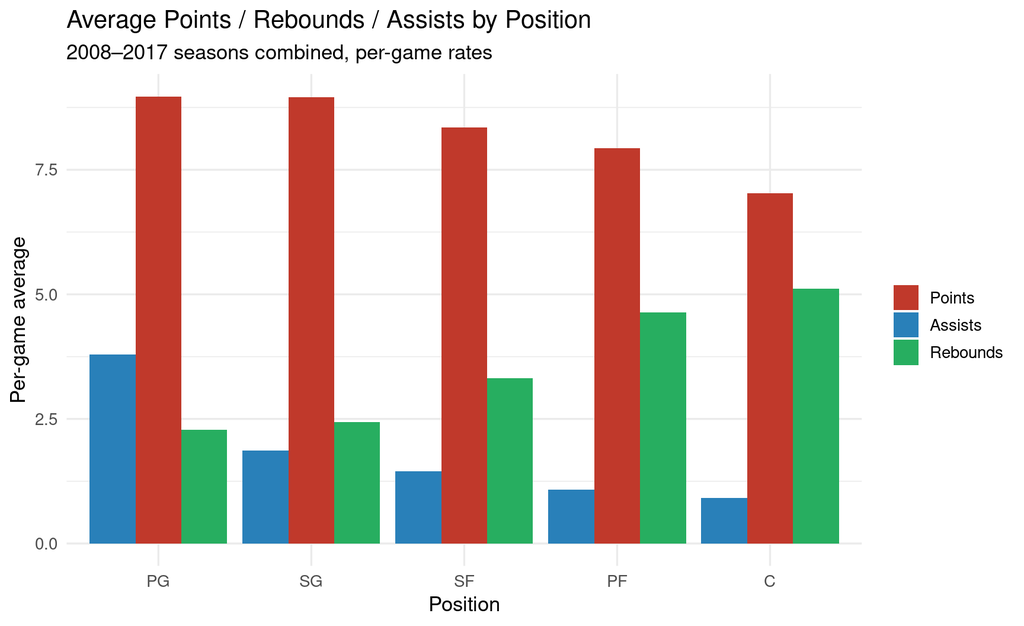

```r
pos_long <- pos_summary %>%
  select(PrimaryPos, Avg_PPG, Avg_RPG, Avg_APG) %>%
  pivot_longer(-PrimaryPos, names_to = "Stat", values_to = "Value")

ggplot(pos_long, aes(x = PrimaryPos, y = Value, fill = Stat)) +
  geom_col(position = "dodge") +
  scale_fill_manual(values = c("Avg_PPG" = "#C0392B", "Avg_APG" = "#2980B9", "Avg_RPG" = "#27AE60"),
                     labels = c("Avg_APG" = "Assists", "Avg_PPG" = "Points", "Avg_RPG" = "Rebounds")) +
  labs(title = "Average Points / Rebounds / Assists by Position",
       subtitle = "2008–2017 seasons combined, per-game rates", x = "Position", y = "Per-game average", fill = NULL) +
  theme_minimal(base_size = 13)
```

## Season Trends: League Scoring & Elite Scorers

Mirrors the Excel “Season Rankings” sheet’s `AVERAGEIFS` (league avg PPG by season) and `COUNTIFS` (count of players averaging 25+ PPG per season, a two-condition count: season AND PPG threshold).

```r
season_trends <- nba %>%
  group_by(Season) %>%
  summarise(
    League_Avg_PPG = mean(PPG, na.rm = TRUE),
    Players_25plus_PPG = sum(PPG >= 25, na.rm = TRUE),
    .groups = "drop"
  )

season_trends
```

| Season | League_Avg_PPG | Players_25plus_PPG |
| --- | --- | --- |
| 2008 | 8.271210 | 5 |
| 2009 | 8.517332 | 6 |
| 2010 | 8.571001 | 7 |
| 2011 | 8.205432 | 7 |
| 2012 | 7.928388 | 4 |
| 2013 | 7.966969 | 5 |
| 2014 | 8.104612 | 5 |
| 2015 | 8.120721 | 4 |
| 2016 | 8.346670 | 6 |
| 2017 | 8.426307 | 13 |

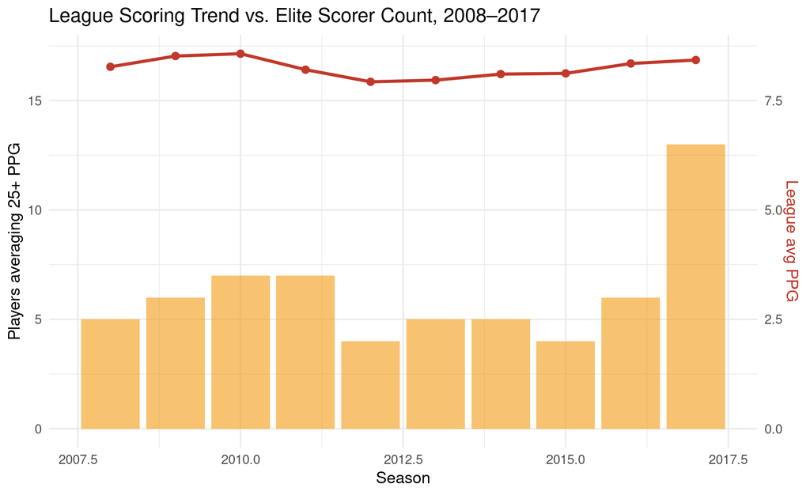

```r
ggplot(season_trends, aes(x = Season)) +
  geom_col(aes(y = Players_25plus_PPG), fill = "#F39C12", alpha = 0.6) +
  geom_line(aes(y = League_Avg_PPG * 2), color = "#C0392B", size = 1.2) +
  geom_point(aes(y = League_Avg_PPG * 2), color = "#C0392B", size = 2.5) +
  scale_y_continuous(
    name = "Players averaging 25+ PPG",
    sec.axis = sec_axis(~ . / 2, name = "League avg PPG")
  ) +
  labs(title = "League Scoring Trend vs. Elite Scorer Count, 2008–2017",
       x = "Season") +
  theme_minimal(base_size = 13) +
  theme(axis.title.y.right = element_text(color = "#C0392B"))
```

## Featured Player Trend & Next-Season Projection

The Excel workbook uses `FORECAST.LINEAR` to fit a straight line through each featured player’s 10 seasons of PPG and project 2018. In R, `lm(PPG ~ Season)` is the direct equivalent — `FORECAST.LINEAR` *is* simple OLS regression under the hood, so this isn’t an approximation, it’s the same calculation.

```r
featured <- c("LeBron James", "Kevin Durant", "Dirk Nowitzki", "Dwyane Wade", "Chris Paul")

featured_data <- nba %>%
  filter(Player %in% featured) %>%
  select(Player, Season, PPG) %>%
  arrange(Player, Season)

# One linear model per player, then predict PPG for the season after their last one.
projections <- featured_data %>%
  group_by(Player) %>%
  group_modify(~ {
    fit <- lm(PPG ~ Season, data = .x)
    next_season <- max(.x$Season) + 1
    pred <- predict(fit, newdata = data.frame(Season = next_season))
    tibble(Season = next_season, PPG = as.numeric(pred), Projected = TRUE)
  }) %>%
  ungroup()

featured_data$Projected <- FALSE
featured_full <- bind_rows(featured_data, projections) %>% arrange(Player, Season)

projections %>% select(Player, Projected_Season = Season, Projected_PPG = PPG)
```

| Player | Projected_Season | Projected_PPG |
| --- | --- | --- |
| Chris Paul | 2018 | 17.74141 |
| Dirk Nowitzki | 2018 | 14.66325 |
| Dwyane Wade | 2018 | 16.76960 |
| Kevin Durant | 2018 | 28.78440 |
| LeBron James | 2018 | 24.75373 |

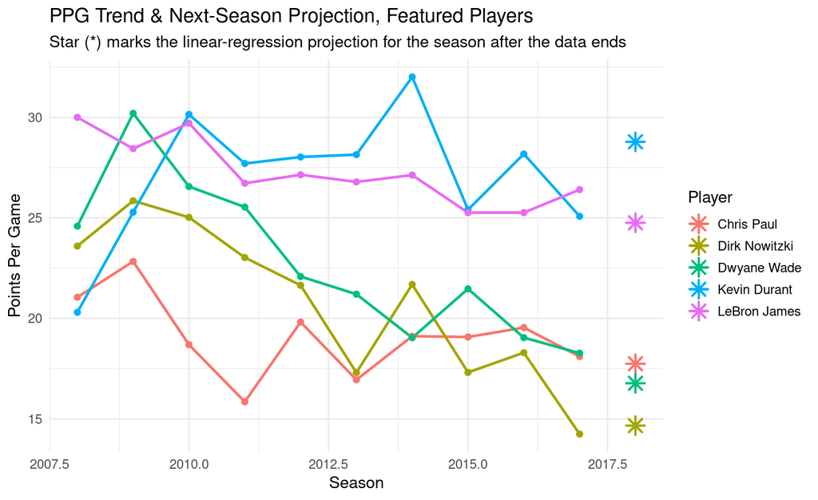

```r
ggplot(featured_full, aes(x = Season, y = PPG, color = Player)) +
  geom_line(data = filter(featured_full, !Projected), size = 1) +
  geom_point(data = filter(featured_full, !Projected), size = 2) +
  geom_point(data = filter(featured_full, Projected), shape = 8, size = 4, stroke = 1.3) +
  labs(title = "PPG Trend & Next-Season Projection, Featured Players",
       subtitle = "Star (*) marks the linear-regression projection for the season after the data ends",
       x = "Season", y = "Points Per Game") +
  theme_minimal(base_size = 13)
```

*Data source: Kaggle — “NBA Players stats since 1950” (filtered to 2008–2017 seasons).*